# Climate change impacts on planned supply–demand match in global wind and solar energy systems

Laibao Liu

Gang He

Mengxi Wu

et al.

November 21, 2024

## Clean energy transition

Wind: ~15; Solar: ~20 $\times$ 2020 level by 2050

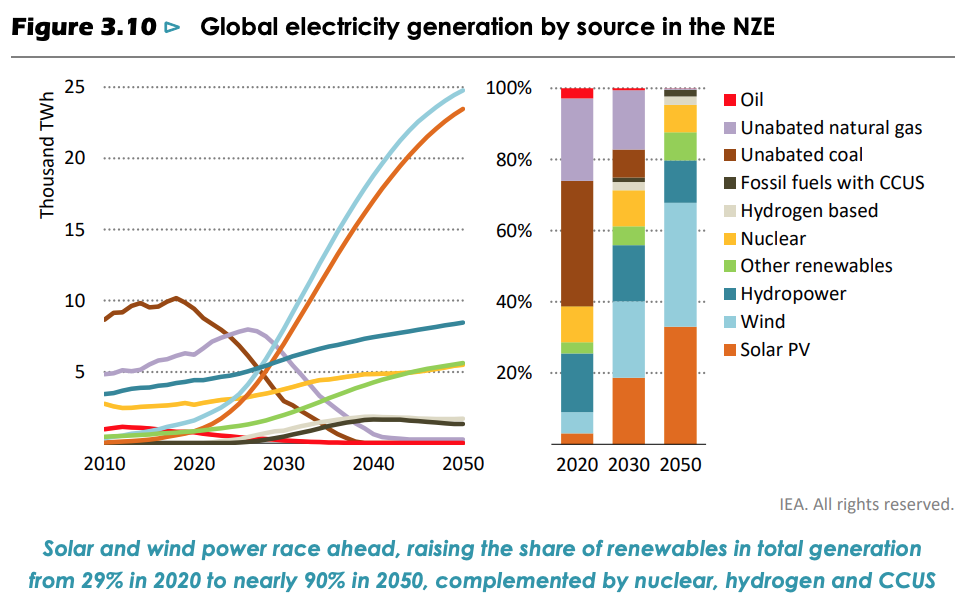

Source: IEA (2021)

## Climate impact on energy systems

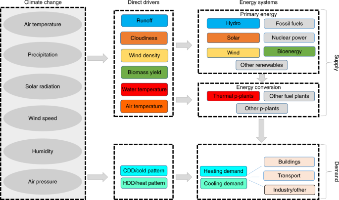

Source: Yalew et al. (2020)

## Supply = Demand

## Supply-demand in concept

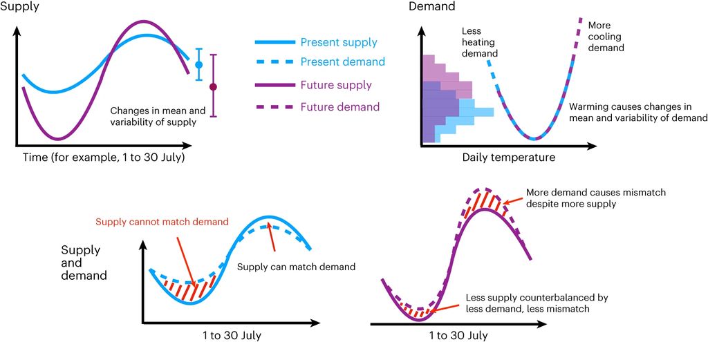

Source: Liu et al. (2023)

## Supply demand match (SDM)

$$SDM=\frac{Supply}{Demand}$$

## Supply demand mismatch (SDMM)

$$SDMM= 100\% - SDM$$

- SDMM frequency
- SDMM intensity

## 12 state-of-the-art GCMs

Present and future climate variables

## Model supply

Climate change

$\downarrow$

wind speed, solar iradiation, temperature

$\downarrow$

Solar, wind generation

## Model demand

Climate change

$\downarrow$

Temperature

$\downarrow$

Heating, cooling demand

## Climate change would reduce SDM

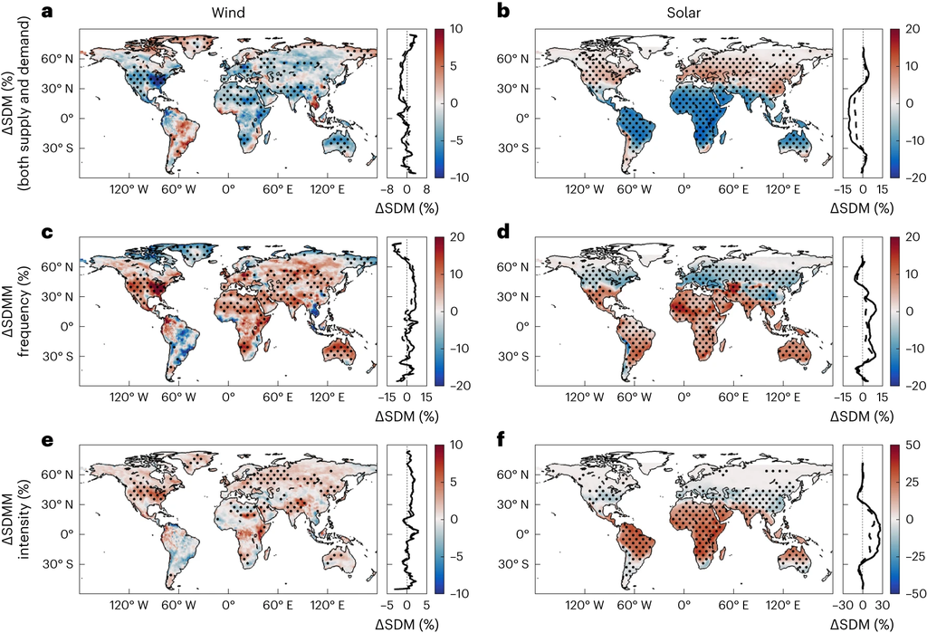

Source: Liu et al. (2023)

## Some regions are impacted more

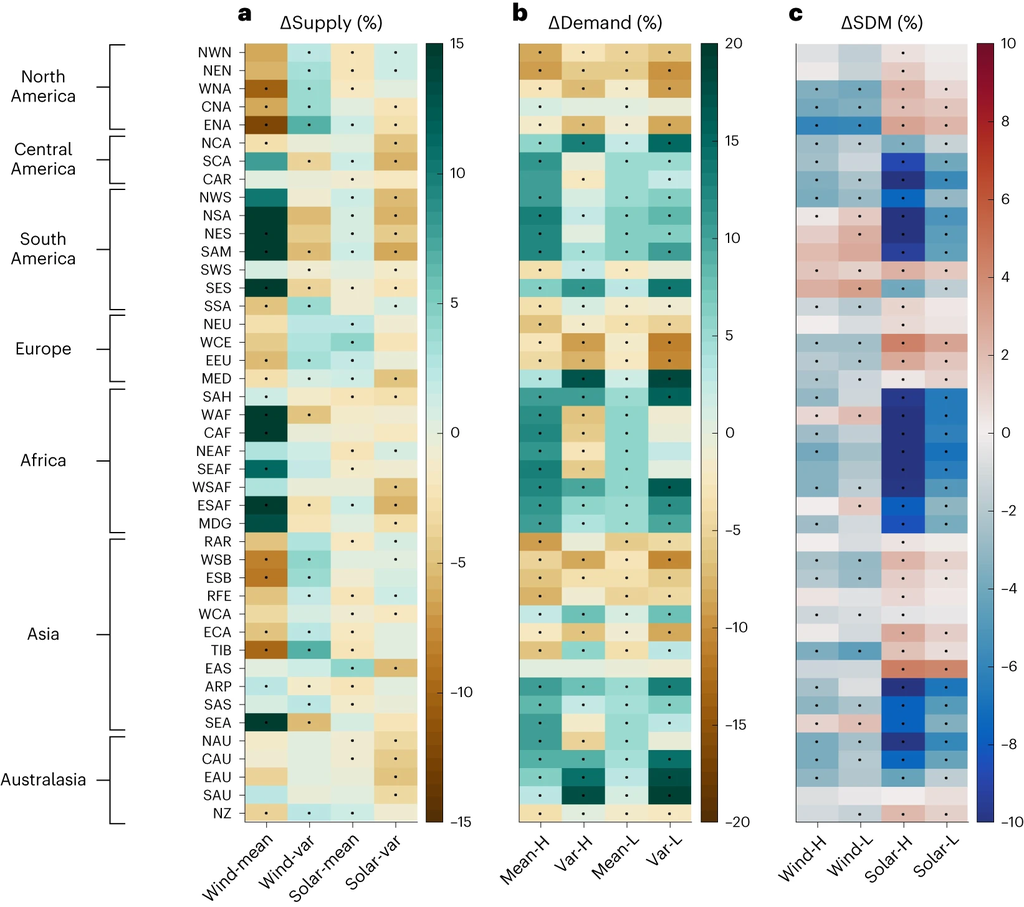

Source: Liu et al. (2023)

## Implications

- First-of-its-kind research quantifying climate impact on renewable energy systems at global scale.
- We may need to build more solar and wind and operate our electric power systems differently to satisfy future demand under climate change.
- It’s important for the policymakers, system planners and operators to develop adapatation strategies.

## NYC example

- 1000 MW by 2030
- $SDM_{present}$
- $\Delta SDM = SDM_{future} - SDM_{present} \sim -10\%$
- NYC would need to build ~110 MW more solar
- More intense and frequent supply demand mismatches

## Next steps

- How to incorporate findings into power system planning and operation?
- Policy responses to enhance grid resilience
- Equity in energy services and climate impacts

## Take home messages

- Fossil fuel energy use created the climate challenge
- Climate impact energy systems too
- Our study defines a new metric: supply demand match, and we found future climate change will reduce the supply demand match
- We may have to build more capacity to address this impact
- Inform climate action and adaptation

## Energy and climate courses

Energy and Climate Policy

[figure not shown]

https://drganghe.github.io/energy-climate-policy/

Energy, Climate, and Society

[figure not shown]

https://drganghe.github.io/energy-climate-society/

## Acknowledgment & Collaboration

- ClimateWorks Foundation
- Collaborators: Laibao Liu (ETH/HKU), Mengxi Wu(UCLA/HKUST), Gang Liu, Haoran Zhang, Ying Chen, Jiashu Shen, Shuangcheng Li (PKU).
- CUNY Institute for Demographic Research

Welcome collaboration with DEEP Energy and Climate Policy Lab:

- Clean energy global supply chain
- Power system decarbonization modeling
- Climate impact on energy systems
- Just energy transition
- Electricity-water-carbon nexus
- Other interdisciplinary aspects of carbon neutrality

Lab: https://deeppolicylab.github.io

E-mail: gang.he@baruch.cuny.edu

### References

IEA. 2021. “Net Zero by 2050.” International Energy Agency.

Liu, Laibao, Gang He, Mengxi Wu, Gang Liu, Haoran Zhang, Ying Chen, Jiashu Shen, and Shuangcheng Li. 2023. “Climate Change Impacts on Planned Supply–Demand Match in Global Wind and Solar Energy Systems.” *Nature Energy* 8 (8): 870–80. https://doi.org/10.1038/s41560-023-01304-w.

Yalew, Seleshi G., Michelle T. H. van Vliet, David E. H. J. Gernaat, Fulco Ludwig, Ariel Miara, Chan Park, Edward Byers, et al. 2020. “Impacts of Climate Change on Energy Systems in Global and Regional Scenarios.” *Nature Energy* 5 (10): 794–802. https://doi.org/10.1038/s41560-020-0664-z.